## NYC Schools Arts Survey Data

The [2017-2018 Arts Survey Data](https://data.cityofnewyork.us/Education/2017-2018-Arts-Survey-Data/475h-cg5t) has data about arts teachers, budgets, partnerships with cultural organizations and parental involvement in NYC public schools.

In an effort to gain greater context for this data, we can examine it in conjuction with publicly available [ELA and Math state test results](https://infohub.nyced.org/reports-and-policies/citywide-information-and-data/test-results) and [demographic data](https://data.cityofnewyork.us/Education/2013-2018-Demographic-Snapshot-School/s52a-8aq6).

My goals were to understand the state of arts programs in NYC schools, what variables affect the resources of arts programs, and whether arts programs have an effect on the academic performance of students.

### Arts Education Liaison

In 2018, 1265 schools were surveyed. Schools were asked whether they have a designated arts supervisor. 5.6%, 72 schools, had no arts supervisor. My first question has to do with whether there is any relation between the presence of an arts supervisor and the demographics of the student population.

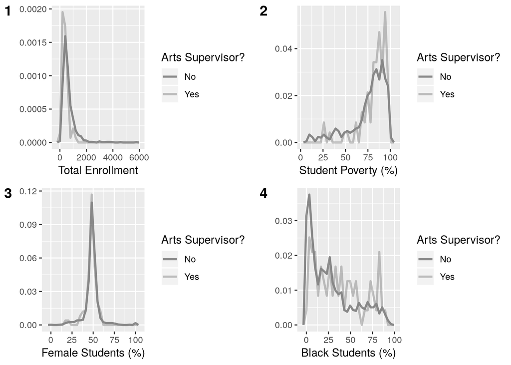

In order to assess the significance of the differences pointed we see above, we can try to fit a logistic regression to the relationship between each variable and the binary response “Does the school have an an arts supervisor?”

These regressions lend support to the differences spotted in the plots of student poverty and race, but the most statistically significant coefficient comes from total enrollment. The coefficient for total enrollment is negative with a p-value below a significance level of 0.001. Percentages of impoverished and black students have positive coefficients with p-values below a significance level of 0.01. As we had assumed from the graphs, there was no significant relation between gender and whether a school had an arts supervisor.  
In order to better interpret these results I converted the standard R logistic regression coefficients into relative risk, [as seen here](https://www.bmj.com/content/348/bmj.f7450.full?ijkey=NHT1YVsoX1RCm8r&keytype=ref).

```
## $total_enrollment_2017
## [1] 0.9975802
##
## $perc_pov_2017
## [1] 1.021338
##
## $perc_black_2017
## [1] 1.012599
```

An increase in total enrollment of one student is associated with a .25% decrease in the likelihood that a school has an arts supervisor. An increase of one percentage point in student poverty and in share of black students is associated with 2.13% and 1.26% increases, respectively, in the likelihood that a school has an arts supervisor.

Consider the possibility that there is confounding between these variables, ie. small schools tend to serve poor, mostly black student populations. To address this possibility I ran a logistic regression upon total enrollment, student poverty and share of black students. This yielded only one significant feature, total enrollment, supporting some sort of statistical interdependence between the variables.  
Let S denote school art supervisor, E enrollment, P poverty and B black students.

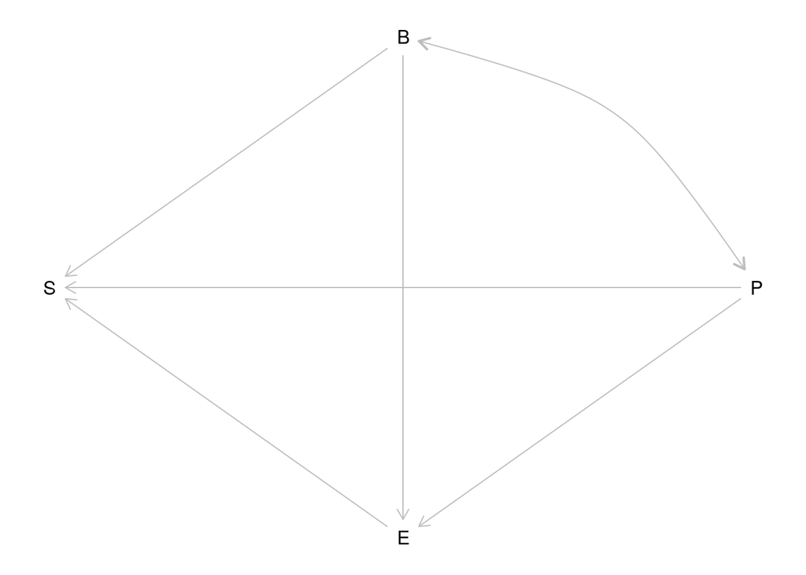

To further investigate confounding, I ran a linear model for total enrollment on percentage of impoverished and black students. As suspected, both had negative relationships with total enrollment. In particular, with a p-value less than significance level 0.001, each additional percentage point of black students was associated with a decrease of 5.22 students.

As a former NYC public school student this coincides with my experience of the school system. In my old neighborhood of Canarsie in Brooklyn was a school previously known as South Shore High School. It served thousands of poor, majority minority students. In 2010, the school was converted into the [South Shore Educational Complex](https://insideschools.org/school/18K515) and now houses five smaller high schools. A naive observer could be expected to assume that small schools have higher faculty:student ratios and more resources to expend on their students. In reality the policies of the NYC DOE have led to the exact opposite, with underperforming schools split up without necessarily being given the resources to turn around their performance.

My second question is whether there is any relation between having an arts supervisor and student academic performance.

```
##
## Call:
## lm(formula = perc_34_all_2018_ela ~ ., data = .)
##
## Residuals:
##     Min      1Q  Median      3Q     Max
## -46.914 -16.395  -3.014  15.136  62.224
##
## Coefficients:
##             Estimate Std. Error t value Pr(>|t|)
## (Intercept)  46.9138     0.6966  67.346  < 2e-16 ***
## Q2_1        -11.0378     2.9472  -3.745 0.000192 ***
## ---
## Signif. codes:  0 '***' 0.001 '**' 0.01 '*' 0.05 '.' 0.1 ' ' 1
##
## Residual standard error: 20.25 on 893 degrees of freedom
##   (370 observations deleted due to missingness)
## Multiple R-squared:  0.01546,    Adjusted R-squared:  0.01436
## F-statistic: 14.03 on 1 and 893 DF,  p-value: 0.0001918
```

```
##
## Call:
## lm(formula = perc_34_all_2018_ela ~ ., data = .)
##
## Residuals:
##     Min      1Q  Median      3Q     Max
## -33.682  -9.306  -1.539   7.298  53.259
##
## Coefficients:
##                        Estimate Std. Error t value Pr(>|t|)
## (Intercept)           94.734711   1.802482  52.558  < 2e-16 ***
## Q2_1                  -2.866684   1.844428  -1.554 0.120483
## perc_pov_2017         -0.638242   0.020032 -31.860  < 2e-16 ***
## perc_black_2017       -0.119648   0.017993  -6.650 5.12e-11 ***
## total_enrollment_2017  0.004533   0.001353   3.350 0.000843 ***
## ---
## Signif. codes:  0 '***' 0.001 '**' 0.01 '*' 0.05 '.' 0.1 ' ' 1
##
## Residual standard error: 12.49 on 890 degrees of freedom
##   (370 observations deleted due to missingness)
## Multiple R-squared:  0.6267, Adjusted R-squared:  0.625
## F-statistic: 373.5 on 4 and 890 DF,  p-value: < 2.2e-16
```

```
##
## Call:
## lm(formula = perc_34_all_2018_math ~ ., data = .)
##
## Residuals:
##     Min      1Q  Median      3Q     Max
## -43.595 -18.795  -4.495  16.955  68.652
##
## Coefficients:
##             Estimate Std. Error t value Pr(>|t|)
## (Intercept)  43.5953     0.7969  54.705  < 2e-16 ***
## Q2_1        -14.0473     3.3716  -4.166  3.4e-05 ***
## ---
## Signif. codes:  0 '***' 0.001 '**' 0.01 '*' 0.05 '.' 0.1 ' ' 1
##
## Residual standard error: 23.17 on 893 degrees of freedom
##   (370 observations deleted due to missingness)
## Multiple R-squared:  0.01907,    Adjusted R-squared:  0.01797
## F-statistic: 17.36 on 1 and 893 DF,  p-value: 3.397e-05
```

```
##
## Call:
## lm(formula = perc_34_all_2018_math ~ ., data = .)
##
## Residuals:
##     Min      1Q  Median      3Q     Max
## -40.137 -10.644  -2.267   8.213  63.174
##
## Coefficients:
##                        Estimate Std. Error t value Pr(>|t|)
## (Intercept)           92.029270   2.178865  42.237  < 2e-16 ***
## Q2_1                  -4.442436   2.229570  -1.993   0.0466 *
## perc_pov_2017         -0.629027   0.024215 -25.976  < 2e-16 ***
## perc_black_2017       -0.219982   0.021750 -10.114  < 2e-16 ***
## total_enrollment_2017  0.006570   0.001636   4.016 6.42e-05 ***
## ---
## Signif. codes:  0 '***' 0.001 '**' 0.01 '*' 0.05 '.' 0.1 ' ' 1
##
## Residual standard error: 15.1 on 890 degrees of freedom
##   (370 observations deleted due to missingness)
## Multiple R-squared:  0.5847, Adjusted R-squared:  0.5828
## F-statistic: 313.2 on 4 and 890 DF,  p-value: < 2.2e-16
```

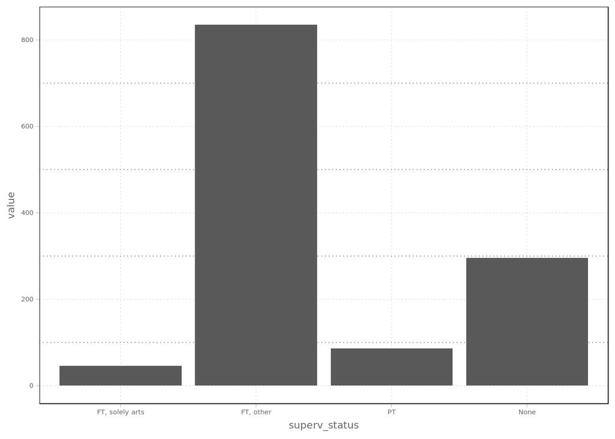

There are many full-time supervisors with duties other than the arts. There are very few part-time supervisors of those working full-time and solely dedicated to the arts.

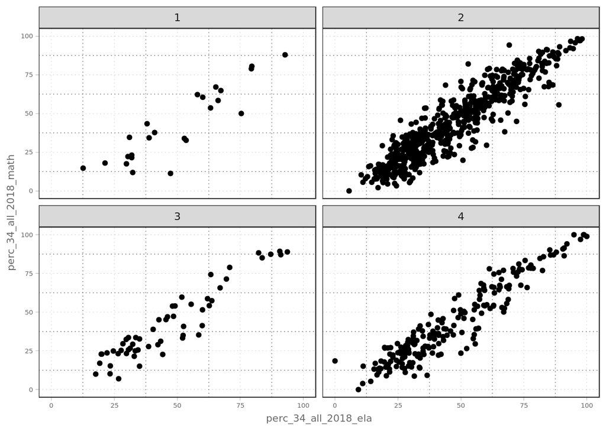

There is a positive relationship between ELA and math scores, regardless of the status of an arts supervisor in the schools.

The next questions are in regard to certifications that the arts supervisor may have, in an arts discipline or in administration. Are there any supervisors certified in an arts discipline and in administration?

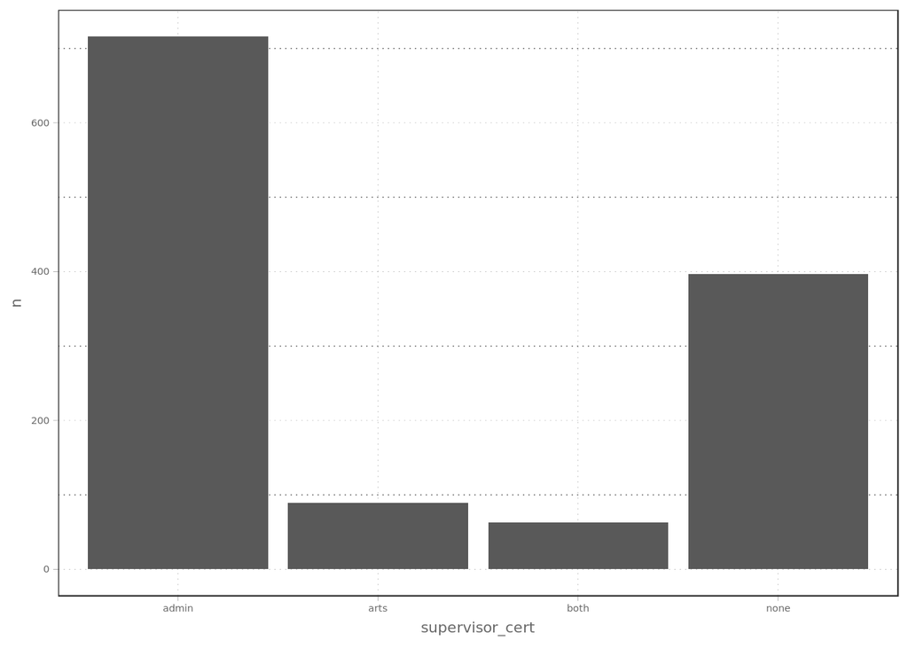

Few supervisors are certified in the arts, the majority are administrators. Could this have an impact on the efficacy of an arts program?

Running a linear regression does not yield a statistically significant result for the effect of supervisor certification on student academic performance.

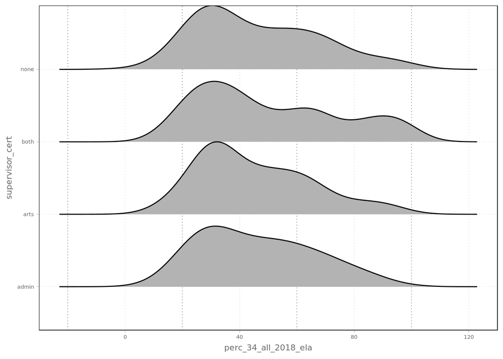

We can see greater density at the high end of academic performance for schools with supervisors who have both certifications, but there is no great difference in the shapes of the different groups.

### Resources devoted to arts education

Schools were asked how many rooms they have dedicated to arts education. This may be useful for assessing the resources that are made available for arts education more broadly.

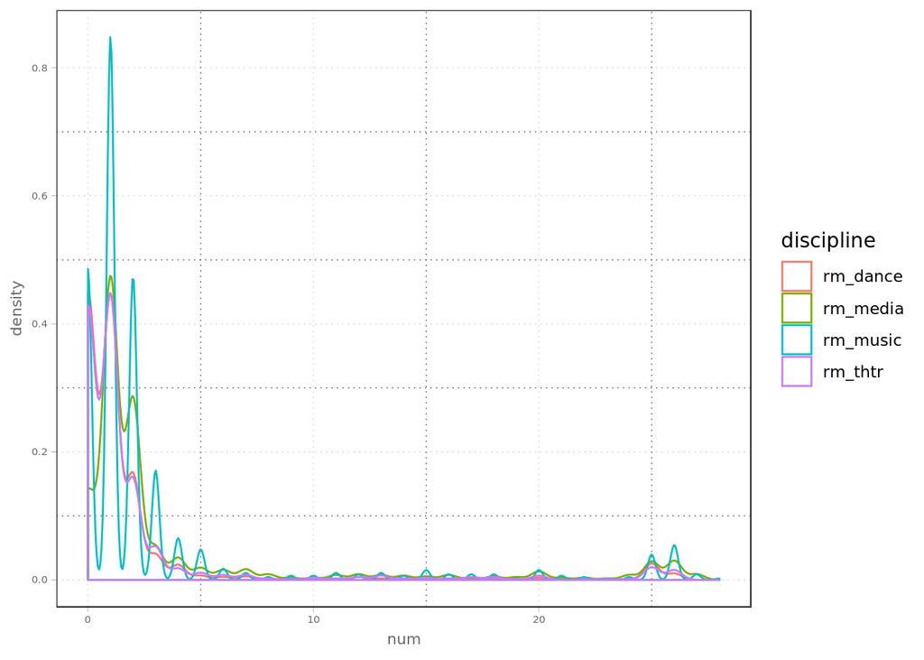

```
##
## Call:
## lm(formula = perc_34_all_2018_ela ~ ., data = .)
##
## Residuals:
##     Min      1Q  Median      3Q     Max
## -39.018 -15.156  -3.264  13.545  58.032
##
## Coefficients:
##                        Estimate Std. Error t value Pr(>|t|)
## (Intercept)           36.922299   1.525820  24.198  < 2e-16 ***
## rm_dance               0.157742   0.196690   0.802    0.423
## rm_music              -0.023840   0.169448  -0.141    0.888
## rm_thtr               -0.094271   0.186768  -0.505    0.614
## rm_media               0.158308   0.133596   1.185    0.236
## total_enrollment_2017  0.014244   0.002227   6.397 2.86e-10 ***
## ---
## Signif. codes:  0 '***' 0.001 '**' 0.01 '*' 0.05 '.' 0.1 ' ' 1
##
## Residual standard error: 19.6 on 717 degrees of freedom
##   (542 observations deleted due to missingness)
## Multiple R-squared:  0.0657, Adjusted R-squared:  0.05918
## F-statistic: 10.08 on 5 and 717 DF,  p-value: 2.41e-09
```

```
##
## Call:
## lm(formula = perc_34_all_2018_math ~ ., data = .)
##
## Residuals:
##     Min      1Q  Median      3Q     Max
## -43.513 -17.688  -5.003  15.169  61.224
##
## Coefficients:
##                        Estimate Std. Error t value Pr(>|t|)
## (Intercept)           30.112034   1.733960  17.366  < 2e-16 ***
## rm_dance               0.127635   0.223521   0.571    0.568
## rm_music               0.135258   0.192563   0.702    0.483
## rm_thtr               -0.015357   0.212246  -0.072    0.942
## rm_media               0.216686   0.151821   1.427    0.154
## total_enrollment_2017  0.018457   0.002531   7.294 7.99e-13 ***
## ---
## Signif. codes:  0 '***' 0.001 '**' 0.01 '*' 0.05 '.' 0.1 ' ' 1
##
## Residual standard error: 22.28 on 717 degrees of freedom
##   (542 observations deleted due to missingness)
## Multiple R-squared:  0.09743,    Adjusted R-squared:  0.09113
## F-statistic: 15.48 on 5 and 717 DF,  p-value: 1.781e-14
```

Conditioning on the effect of school size, through total enrollment, there is no statistically significant effect of the number of rooms for arts education on student academic performance.

We can also consider the technological resources available to students. Here we are referring to the various software, computers, cameras, and so on that can be made available for use in the arts. We do not have data on musical instruments for music or props for theater, although it is certainly the case that those resources are important in running an effective arts program.

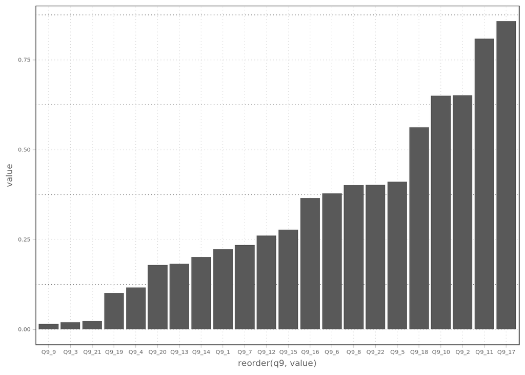

```
##
## Call:
## lm(formula = perc_34_4_2018_ela ~ ., data = .)
##
## Residuals:
##     Min      1Q  Median      3Q     Max
## -55.956 -16.542  -1.248  15.472  54.524
##
## Coefficients:
##             Estimate Std. Error t value Pr(>|t|)
## (Intercept)  45.1120     2.9220  15.439  < 2e-16 ***
## Q9_1          8.0742     2.5576   3.157  0.00167 **
## Q9_2          4.6313     2.1191   2.186  0.02923 *
## Q9_3        -13.2727    12.7274  -1.043  0.29744
## Q9_4         -8.7560     3.4242  -2.557  0.01080 *
## Q9_5         -1.3037     2.3035  -0.566  0.57162
## Q9_6         -4.5362     2.6468  -1.714  0.08706 .
## Q9_7          1.0429     3.1373   0.332  0.73969
## Q9_8          0.9758     2.1418   0.456  0.64884
## Q9_9         -0.8208     6.8006  -0.121  0.90397
## Q9_10         2.3505     2.2497   1.045  0.29652
## Q9_11         1.4500     2.4851   0.583  0.55979
## Q9_12         4.2245     2.3563   1.793  0.07350 .
## Q9_13        -0.9965     2.5655  -0.388  0.69785
## Q9_14         4.3227     2.9732   1.454  0.14650
## Q9_15        -1.6710     2.9039  -0.575  0.56520
## Q9_16         3.6648     2.2933   1.598  0.11056
## Q9_17        -1.6582     2.9718  -0.558  0.57707
## Q9_18         1.6558     2.1116   0.784  0.43327
## Q9_19        -7.0471     3.5178  -2.003  0.04559 *
## Q9_20        -1.6120     2.2735  -0.709  0.47858
## Q9_21        -1.0394     8.7525  -0.119  0.90551
## Q9_22        -1.2279     2.0635  -0.595  0.55203
## ---
## Signif. codes:  0 '***' 0.001 '**' 0.01 '*' 0.05 '.' 0.1 ' ' 1
##
## Residual standard error: 21.19 on 605 degrees of freedom
##   (637 observations deleted due to missingness)
## Multiple R-squared:  0.07654,    Adjusted R-squared:  0.04296
## F-statistic: 2.279 on 22 and 605 DF,  p-value: 0.0008077
```

```
##
## Call:
## lm(formula = perc_34_4_2018_math ~ ., data = .)
##
## Residuals:
##     Min      1Q  Median      3Q     Max
## -57.638 -18.377  -1.748  16.261  60.212
##
## Coefficients:
##             Estimate Std. Error t value Pr(>|t|)
## (Intercept)  39.9664     3.2330  12.362   <2e-16 ***
## Q9_1          6.9231     2.8298   2.446   0.0147 *
## Q9_2          4.0004     2.3475   1.704   0.0889 .
## Q9_3         -9.9910    14.0818  -0.709   0.4783
## Q9_4         -9.9140     3.7886  -2.617   0.0091 **
## Q9_5         -1.8052     2.5487  -0.708   0.4791
## Q9_6         -4.9006     2.9285  -1.673   0.0948 .
## Q9_7          1.1604     3.4712   0.334   0.7383
## Q9_8          3.6596     2.3699   1.544   0.1231
## Q9_9          2.0624     7.5244   0.274   0.7841
## Q9_10         3.2859     2.4912   1.319   0.1877
## Q9_11         1.3572     2.7511   0.493   0.6220
## Q9_12         3.2834     2.6071   1.259   0.2084
## Q9_13        -0.7871     2.8385  -0.277   0.7817
## Q9_14         5.1276     3.2897   1.559   0.1196
## Q9_15        -0.3295     3.2129  -0.103   0.9183
## Q9_16         4.6559     2.5374   1.835   0.0670 .
## Q9_17        -1.5432     3.2889  -0.469   0.6391
## Q9_18         1.9250     2.3372   0.824   0.4105
## Q9_19        -6.6242     3.8922  -1.702   0.0893 .
## Q9_20        -2.3976     2.5158  -0.953   0.3410
## Q9_21        -2.8880     9.6840  -0.298   0.7656
## Q9_22        -1.7924     2.2833  -0.785   0.4328
## ---
## Signif. codes:  0 '***' 0.001 '**' 0.01 '*' 0.05 '.' 0.1 ' ' 1
##
## Residual standard error: 23.44 on 604 degrees of freedom
##   (638 observations deleted due to missingness)
## Multiple R-squared:  0.0744, Adjusted R-squared:  0.04069
## F-statistic: 2.207 on 22 and 604 DF,  p-value: 0.001276
```

```
## [1] "M" "X" "Q" "K" "R"
```

```
##
## Call:
## lm(formula = perc_34_4_2018_ela ~ ., data = .)
##
## Residuals:
##     Min      1Q  Median      3Q     Max
## -48.037 -14.916   0.064  13.808  48.342
##
## Coefficients: (1 not defined because of singularities)
##             Estimate Std. Error t value Pr(>|t|)
## (Intercept)   58.066      3.169  18.325  < 2e-16 ***
## K             -7.808      3.487  -2.239   0.0255 *
## X            -22.763      3.674  -6.196 1.06e-09 ***
## M             -2.531      3.699  -0.684   0.4940
## Q             -2.029      3.549  -0.572   0.5678
## R                 NA         NA      NA       NA
## ---
## Signif. codes:  0 '***' 0.001 '**' 0.01 '*' 0.05 '.' 0.1 ' ' 1
##
## Residual standard error: 20.29 on 623 degrees of freedom
##   (637 observations deleted due to missingness)
## Multiple R-squared:  0.128,  Adjusted R-squared:  0.1224
## F-statistic: 22.86 on 4 and 623 DF,  p-value: < 2.2e-16
```

```
##
## Call:
## lm(formula = perc_34_4_2018_math ~ ., data = .)
##
## Residuals:
##     Min      1Q  Median      3Q     Max
## -50.629 -15.804  -1.692  16.935  67.908
##
## Coefficients: (1 not defined because of singularities)
##             Estimate Std. Error t value Pr(>|t|)
## (Intercept)   50.578      3.505  14.429  < 2e-16 ***
## K             -4.577      3.858  -1.186    0.236
## X            -20.286      4.065  -4.991 7.82e-07 ***
## M              0.738      4.097   0.180    0.857
## Q              4.051      3.926   1.032    0.303
## R                 NA         NA      NA       NA
## ---
## Signif. codes:  0 '***' 0.001 '**' 0.01 '*' 0.05 '.' 0.1 ' ' 1
##
## Residual standard error: 22.45 on 622 degrees of freedom
##   (638 observations deleted due to missingness)
## Multiple R-squared:  0.1261, Adjusted R-squared:  0.1205
## F-statistic: 22.44 on 4 and 622 DF,  p-value: < 2.2e-16
```

```
##
## Call:
## lm(formula = perc_34_4_2018_ela ~ ., data = .)
##
## Residuals:
##     Min      1Q  Median      3Q     Max
## -29.851 -10.014  -1.848   8.259  62.448
##
## Coefficients: (1 not defined because of singularities)
##                 Estimate Std. Error t value Pr(>|t|)
## (Intercept)     96.54509    2.63129  36.691  < 2e-16 ***
## perc_black_2017 -0.15899    0.02299  -6.916 1.16e-11 ***
## perc_pov_2017   -0.60067    0.02699 -22.258  < 2e-16 ***
## K                5.49066    2.40857   2.280   0.0230 *
## X               -4.02935    2.57617  -1.564   0.1183
## M               -0.59157    2.49283  -0.237   0.8125
## Q                4.67516    2.40369   1.945   0.0522 .
## R                     NA         NA      NA       NA
## ---
## Signif. codes:  0 '***' 0.001 '**' 0.01 '*' 0.05 '.' 0.1 ' ' 1
##
## Residual standard error: 13.66 on 621 degrees of freedom
##   (637 observations deleted due to missingness)
## Multiple R-squared:  0.6057, Adjusted R-squared:  0.6019
## F-statistic:   159 on 6 and 621 DF,  p-value: < 2.2e-16
```

```
## [1] 72
```

```
##
## Call:
## lm(formula = Q2_1 ~ ., data = .)
##
## Residuals:
##      Min       1Q   Median       3Q      Max
## -0.07278 -0.07278 -0.06164 -0.03679  0.96321
##
## Coefficients: (1 not defined because of singularities)
##              Estimate Std. Error t value Pr(>|t|)
## (Intercept) 2.809e-16  2.848e-02   0.000   1.0000
## K           7.278e-02  3.091e-02   2.355   0.0187 *
## X           6.164e-02  3.153e-02   1.955   0.0508 .
## M           6.751e-02  3.220e-02   2.097   0.0362 *
## Q           3.679e-02  3.146e-02   1.169   0.2425
## R                  NA         NA      NA       NA
## ---
## Signif. codes:  0 '***' 0.001 '**' 0.01 '*' 0.05 '.' 0.1 ' ' 1
##
## Residual standard error: 0.2314 on 1260 degrees of freedom
## Multiple R-squared:  0.006795,   Adjusted R-squared:  0.003642
## F-statistic: 2.155 on 4 and 1260 DF,  p-value: 0.07199
```

```
##
## Call:
## lm(formula = Q2_1 ~ ., data = .)
##
## Residuals:
##      Min       1Q   Median       3Q      Max
## -0.11243 -0.07315 -0.05853 -0.03256  0.99929
##
## Coefficients: (1 not defined because of singularities)
##                   Estimate Std. Error t value Pr(>|t|)
## (Intercept)     -0.0444269  0.0358094  -1.241   0.2150
## perc_pov_2017    0.0005775  0.0003666   1.575   0.1154
## perc_black_2017  0.0005412  0.0002858   1.894   0.0585 .
## K                0.0491204  0.0318370   1.543   0.1231
## X                0.0414626  0.0326412   1.270   0.2042
## M                0.0605968  0.0322038   1.882   0.0601 .
## Q                0.0280573  0.0315692   0.889   0.3743
## R                       NA         NA      NA       NA
## ---
## Signif. codes:  0 '***' 0.001 '**' 0.01 '*' 0.05 '.' 0.1 ' ' 1
##
## Residual standard error: 0.2307 on 1258 degrees of freedom
## Multiple R-squared:  0.01375,    Adjusted R-squared:  0.009043
## F-statistic: 2.922 on 6 and 1258 DF,  p-value: 0.007793
```

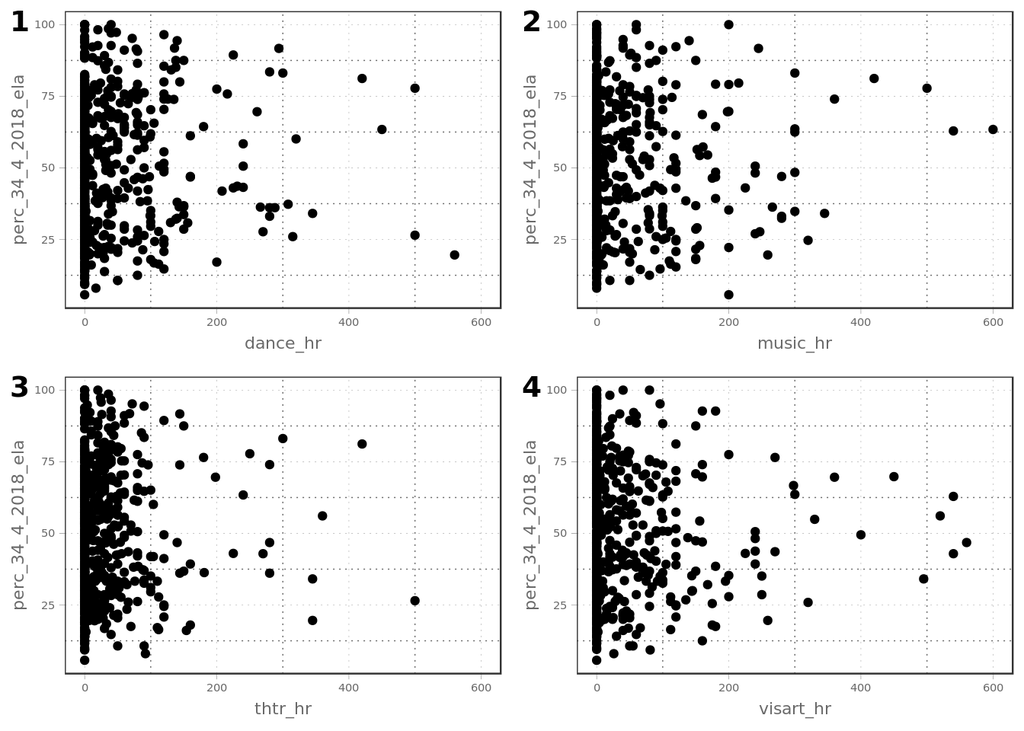

```
##
## Call:
## lm(formula = perc_34_4_2018_ela ~ ., data = .)
##
## Residuals:
##     Min      1Q  Median      3Q     Max
## -45.793 -17.278  -1.277  16.812  49.783
##
## Coefficients:
##              Estimate Std. Error t value Pr(>|t|)
## (Intercept) 50.578260   0.873733  57.888   <2e-16 ***
## dance_hr    -0.009032   0.006419  -1.407   0.1599
## music_hr     0.004575   0.005636   0.812   0.4173
## thtr_hr      0.009424   0.006519   1.446   0.1488
## visart_hr   -0.005076   0.002546  -1.994   0.0466 *
## ---
## Signif. codes:  0 '***' 0.001 '**' 0.01 '*' 0.05 '.' 0.1 ' ' 1
##
## Residual standard error: 21.65 on 623 degrees of freedom
##   (637 observations deleted due to missingness)
## Multiple R-squared:  0.007003,   Adjusted R-squared:  0.0006273
## F-statistic: 1.098 on 4 and 623 DF,  p-value: 0.3564
```

```
##
## Call:
## lm(formula = perc_34_4_2018_math ~ ., data = .)
##
## Residuals:
##     Min      1Q  Median      3Q     Max
## -45.095 -19.734  -2.122  19.450  53.195
##
## Coefficients:
##               Estimate Std. Error t value Pr(>|t|)
## (Intercept) 46.7403413  0.9664724  48.362   <2e-16 ***
## dance_hr    -0.0047613  0.0070945  -0.671   0.5024
## music_hr     0.0004887  0.0062289   0.078   0.9375
## thtr_hr      0.0093852  0.0072055   1.302   0.1932
## visart_hr   -0.0055205  0.0028137  -1.962   0.0502 .
## ---
## Signif. codes:  0 '***' 0.001 '**' 0.01 '*' 0.05 '.' 0.1 ' ' 1
##
## Residual standard error: 23.93 on 622 degrees of freedom
##   (638 observations deleted due to missingness)
## Multiple R-squared:  0.006772,   Adjusted R-squared:  0.0003845
## F-statistic:  1.06 on 4 and 622 DF,  p-value: 0.3754
```

```
## [1] 27
```

Only 27 screened arts programs in NYC schools.

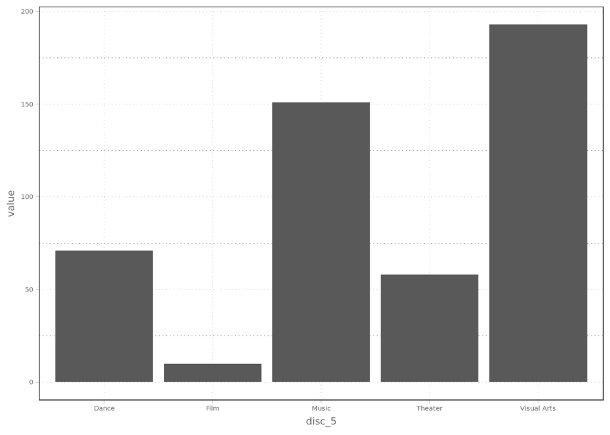

```
##
## Call:
## lm(formula = perc_34_7_2018_ela ~ ., data = .)
##
## Residuals:
##     Min      1Q  Median      3Q     Max
## -40.618 -17.252  -6.353  13.739  63.891
##
## Coefficients:
##             Estimate Std. Error t value Pr(>|t|)
## (Intercept)  36.1094     1.7039  21.193   <2e-16 ***
## Q22_R1_C1     0.9779     3.4509   0.283   0.7770
## Q22_R2_C1     6.5812     7.7396   0.850   0.3957
## Q22_R3_C1     6.6436     2.8725   2.313   0.0213 *
## Q22_R4_C1     0.1020     3.6669   0.028   0.9778
## Q22_R5_C1     3.3629     2.7579   1.219   0.2235
## ---
## Signif. codes:  0 '***' 0.001 '**' 0.01 '*' 0.05 '.' 0.1 ' ' 1
##
## Residual standard error: 22.4 on 361 degrees of freedom
##   (898 observations deleted due to missingness)
## Multiple R-squared:  0.04519,    Adjusted R-squared:  0.03197
## F-statistic: 3.417 on 5 and 361 DF,  p-value: 0.00497
```

```
##
## Call:
## lm(formula = perc_34_7_2018_math ~ ., data = .)
##
## Residuals:
##     Min      1Q  Median      3Q     Max
## -44.704 -18.770  -7.984  16.516  70.258
##
## Coefficients:
##             Estimate Std. Error t value Pr(>|t|)
## (Intercept)  29.7419     1.9068  15.598   <2e-16 ***
## Q22_R1_C1     0.5512     3.8395   0.144   0.8859
## Q22_R2_C1     8.6402     8.6112   1.003   0.3164
## Q22_R3_C1     8.0646     3.1967   2.523   0.0121 *
## Q22_R4_C1    -0.1715     4.0799  -0.042   0.9665
## Q22_R5_C1     4.5774     3.0719   1.490   0.1371
## ---
## Signif. codes:  0 '***' 0.001 '**' 0.01 '*' 0.05 '.' 0.1 ' ' 1
##
## Residual standard error: 24.92 on 359 degrees of freedom
##   (900 observations deleted due to missingness)
## Multiple R-squared:  0.05463,    Adjusted R-squared:  0.04146
## F-statistic: 4.149 on 5 and 359 DF,  p-value: 0.001121
```

### Funding

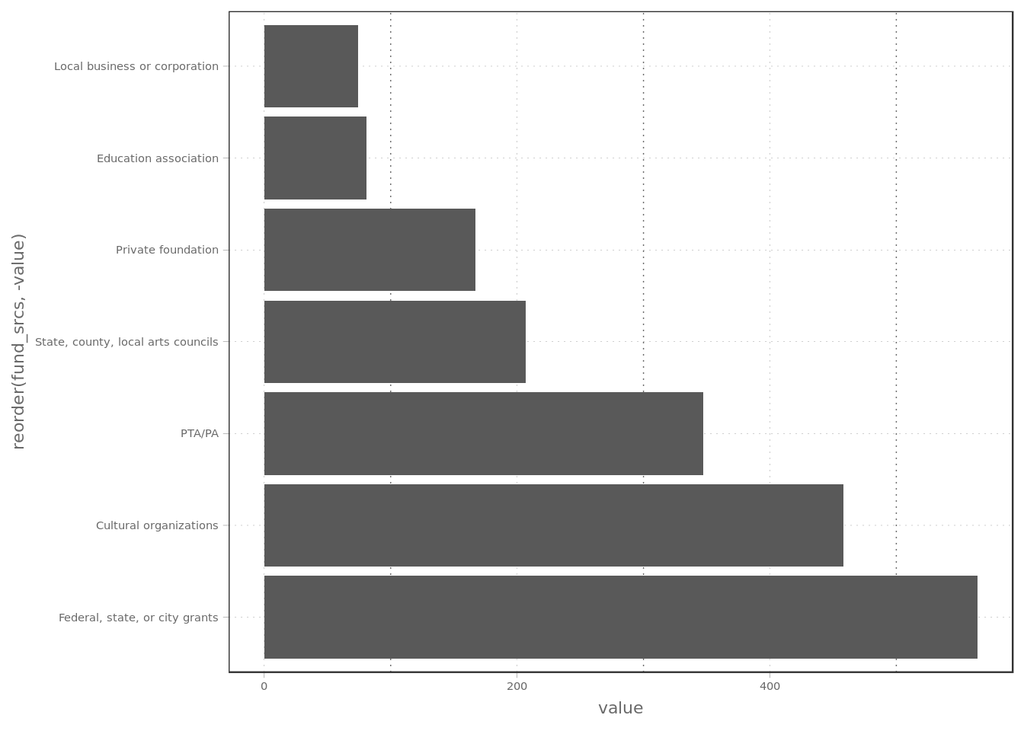

Government grants are the most common source of non-DOE funding, followed by cultural organizations, and PTA. Then arts councils, private foundations, educational associations and local business.

Does poverty predict the different sources of funding?

```
## [1] "Q36_R1_C1"
##
## Call:
## glm(formula = unlist(temp[, 1]) ~ unlist(temp[, 2]), family = "binomial")
##
## Deviance Residuals:
##     Min       1Q   Median       3Q      Max
## -0.9546  -0.9507  -0.9457   1.4214   1.4475
##
## Coefficients:
##                     Estimate Std. Error z value Pr(>|z|)
## (Intercept)       -0.6220979  0.2309460  -2.694  0.00707 **
## unlist(temp[, 2])  0.0007276  0.0029200   0.249  0.80321
## ---
## Signif. codes:  0 '***' 0.001 '**' 0.01 '*' 0.05 '.' 0.1 ' ' 1
##
## (Dispersion parameter for binomial family taken to be 1)
##
##     Null deviance: 1656.1  on 1264  degrees of freedom
## Residual deviance: 1656.1  on 1263  degrees of freedom
## AIC: 1660.1
##
## Number of Fisher Scoring iterations: 4
##
## [1] "Q36_R2_C1"
##
## Call:
## glm(formula = unlist(temp[, 1]) ~ unlist(temp[, 2]), family = "binomial")
##
## Deviance Residuals:
##     Min       1Q   Median       3Q      Max
## -0.3869  -0.3767  -0.3676  -0.3516   2.4722
##
## Coefficients:
##                    Estimate Std. Error z value Pr(>|z|)
## (Intercept)       -3.121984   0.496853  -6.284 3.31e-10 ***
## unlist(temp[, 2])  0.005683   0.006173   0.921    0.357
## ---
## Signif. codes:  0 '***' 0.001 '**' 0.01 '*' 0.05 '.' 0.1 ' ' 1
##
```

[output cut: 112 more lines]

```
##
## Coefficients:
##                    Estimate Std. Error z value Pr(>|z|)
## (Intercept)       -1.030669   0.272573  -3.781 0.000156 ***
## unlist(temp[, 2]) -0.007975   0.003526  -2.262 0.023720 *
## ---
## Signif. codes:  0 '***' 0.001 '**' 0.01 '*' 0.05 '.' 0.1 ' ' 1
##
## (Dispersion parameter for binomial family taken to be 1)
##
##     Null deviance: 1127.5  on 1264  degrees of freedom
## Residual deviance: 1122.6  on 1263  degrees of freedom
## AIC: 1126.6
##
## Number of Fisher Scoring iterations: 4
```

Sources that are not predicted with statistical significance: Cultural organizations, education associations, government grants, local business, private foundations.  
Poverty is negatively associated with PTA/PA at a *** sig. Local arts councils is similar but at a * sig. This could be picking up the effect of specific neighborhoods?

```
## [1] "Q36_R1_C1"
##
## Call:
## glm(formula = unlist(temp[, 1]) ~ unlist(temp[, 2]) + unlist(temp[,
##     3]), family = "binomial")
##
## Deviance Residuals:
##     Min       1Q   Median       3Q      Max
## -1.0158  -0.9636  -0.9149   1.3940   1.5594
##
## Coefficients:
##                    Estimate Std. Error z value Pr(>|z|)
## (Intercept)       -0.641246   0.231106  -2.775  0.00553 **
## unlist(temp[, 2])  0.002573   0.003093   0.832  0.40548
## unlist(temp[, 3]) -0.004386   0.002460  -1.783  0.07462 .
## ---
## Signif. codes:  0 '***' 0.001 '**' 0.01 '*' 0.05 '.' 0.1 ' ' 1
##
## (Dispersion parameter for binomial family taken to be 1)
##
##     Null deviance: 1656.1  on 1264  degrees of freedom
## Residual deviance: 1652.8  on 1262  degrees of freedom
## AIC: 1658.8
##
## Number of Fisher Scoring iterations: 4
##
## [1] "Q36_R2_C1"
##
## Call:
## glm(formula = unlist(temp[, 1]) ~ unlist(temp[, 2]) + unlist(temp[,
##     3]), family = "binomial")
##
## Deviance Residuals:
##     Min       1Q   Median       3Q      Max
## -0.4382  -0.3894  -0.3623  -0.3241   2.5048
##
## Coefficients:
##                    Estimate Std. Error z value Pr(>|z|)
## (Intercept)       -3.151905   0.495007  -6.367 1.92e-10 ***
## unlist(temp[, 2])  0.008748   0.006427   1.361    0.174
```

[output cut: 126 more lines]

```
## Coefficients:
##                     Estimate Std. Error z value Pr(>|z|)
## (Intercept)       -1.0340478  0.2729554  -3.788 0.000152 ***
## unlist(temp[, 2]) -0.0076747  0.0037846  -2.028 0.042575 *
## unlist(temp[, 3]) -0.0006978  0.0032171  -0.217 0.828285
## ---
## Signif. codes:  0 '***' 0.001 '**' 0.01 '*' 0.05 '.' 0.1 ' ' 1
##
## (Dispersion parameter for binomial family taken to be 1)
##
##     Null deviance: 1127.5  on 1264  degrees of freedom
## Residual deviance: 1122.5  on 1262  degrees of freedom
## AIC: 1128.5
##
## Number of Fisher Scoring iterations: 4
```

Conditioning on poverty and percentage of black students yields a positive relationship with poverty for government grants and a negative relationship with poverty for PTA/PA funding (negative with black students for both).

```
## [1] "Q36_R1_C1"
##
## Call:
## glm(formula = unlist(temp[, 1]) ~ unlist(temp[, 2]) + unlist(temp[,
##     3]) + unlist(temp[, 4]) + unlist(temp[, 5]) + unlist(temp[,
##     6]), family = "binomial")
##
## Deviance Residuals:
##     Min       1Q   Median       3Q      Max
## -1.1478  -1.0237  -0.9489   1.3278   1.5654
##
## Coefficients:
##                     Estimate Std. Error z value Pr(>|z|)
## (Intercept)        0.1259423  0.6023767   0.209    0.834
## unlist(temp[, 2]) -0.0016509  0.0048407  -0.341    0.733
## unlist(temp[, 3]) -0.0049303  0.0031723  -1.554    0.120
## unlist(temp[, 4])  0.0001065  0.0002215   0.481    0.631
## unlist(temp[, 5]) -0.0044109  0.0100711  -0.438    0.661
## unlist(temp[, 6]) -0.0034122  0.0083144  -0.410    0.682
##
## (Dispersion parameter for binomial family taken to be 1)
##
##     Null deviance: 1203.9  on 894  degrees of freedom
## Residual deviance: 1199.3  on 889  degrees of freedom
##   (370 observations deleted due to missingness)
## AIC: 1211.3
##
## Number of Fisher Scoring iterations: 4
##
## [1] "Q36_R2_C1"
##
## Call:
## glm(formula = unlist(temp[, 1]) ~ unlist(temp[, 2]) + unlist(temp[,
##     3]) + unlist(temp[, 4]) + unlist(temp[, 5]) + unlist(temp[,
##     6]), family = "binomial")
##
## Deviance Residuals:
##     Min       1Q   Median       3Q      Max
## -0.5433  -0.4024  -0.3559  -0.3053   2.7503
##
```

[output cut: 159 more lines]

```
## unlist(temp[, 3])  0.0028032  0.0040356   0.695  0.48728
## unlist(temp[, 4])  0.0007264  0.0002602   2.791  0.00525 **
## unlist(temp[, 5])  0.0027445  0.0126894   0.216  0.82877
## unlist(temp[, 6])  0.0065102  0.0105057   0.620  0.53547
## ---
## Signif. codes:  0 '***' 0.001 '**' 0.01 '*' 0.05 '.' 0.1 ' ' 1
##
## (Dispersion parameter for binomial family taken to be 1)
##
##     Null deviance: 870.19  on 894  degrees of freedom
## Residual deviance: 854.37  on 889  degrees of freedom
##   (370 observations deleted due to missingness)
## AIC: 866.37
##
## Number of Fisher Scoring iterations: 4
```

Controlling for poverty, percentage of black students, total enrollment, and academic performance yields a statistically significant negative relationship for poverty and a positive for math performance on PTA/PA funding, and a positive relationship for total enrollment on state funding.

### Parental Involvement

```
## # A tibble: 109 x 2
## # Groups:   Q39_4 [109]
##    Q39_4                                     n
##    <chr>                                 <int>
##  1 0                                      1155
##  2 adult learning arts class through CBO     1
##  3 after school art program for adults       1
##  4 after-school workshops                    1
##  5 Arranging our talent show                 1
##  6 Art class                                 1
##  7 Art focused workshops for parents         1
##  8 Art Parent Workshop                       1
##  9 Art parent Workshops                      1
## 10 Art to Remember                           1
## # … with 99 more rows
```

It could be neat to analyze the ‘Other’ category. For now I’ll move the comments over and replace them with 1s.

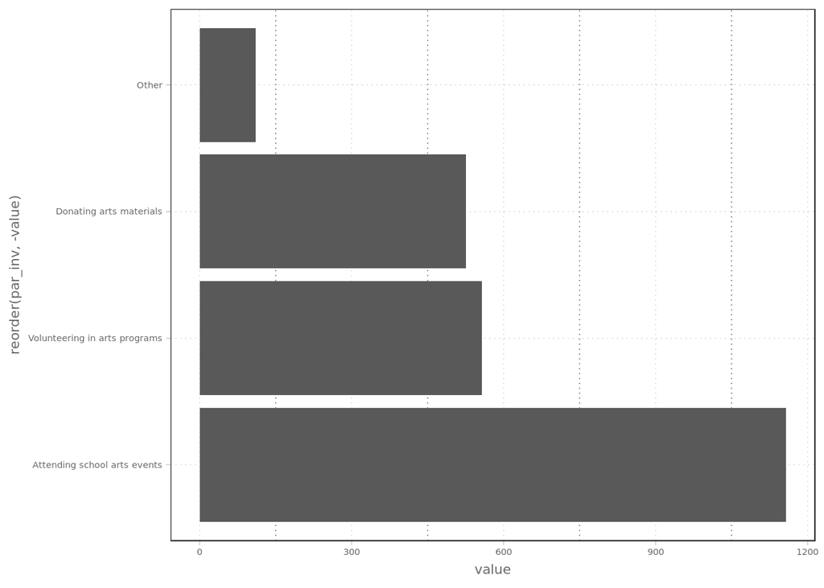

Parental participation is most common through attending school events, to be expected. Fewer parents volunteer or donate art materials.

Is there a relationship between poverty and volunteering in arts programs, Q39_2?

```
##
## Call:
## glm(formula = Q39_2 ~ ., family = "binomial", data = .)
##
## Deviance Residuals:
##     Min       1Q   Median       3Q      Max
## -1.8912  -1.1041   0.7158   1.1117   1.4785
##
## Coefficients:
##                         Estimate Std. Error z value Pr(>|z|)
## (Intercept)            0.5676743  0.6013347   0.944  0.34516
## perc_pov_2017         -0.0137619  0.0050651  -2.717  0.00659 **
## total_enrollment_2017  0.0003847  0.0002175   1.768  0.07699 .
## perc_34_all_2018_ela  -0.0041887  0.0100464  -0.417  0.67673
## perc_34_all_2018_math  0.0139498  0.0080545   1.732  0.08329 .
## ---
## Signif. codes:  0 '***' 0.001 '**' 0.01 '*' 0.05 '.' 0.1 ' ' 1
##
## (Dispersion parameter for binomial family taken to be 1)
##
##     Null deviance: 1235.4  on 894  degrees of freedom
## Residual deviance: 1174.4  on 890  degrees of freedom
##   (370 observations deleted due to missingness)
## AIC: 1184.4
##
## Number of Fisher Scoring iterations: 4
```

There is a strong negative relation between poverty and parental volunteers in arts programs, even controlling for school size and academic performance.

Is there a relationship between poverty and donating arts materials, Q39_3?

```
##
## Call:
## glm(formula = Q39_3 ~ ., family = "binomial", data = .)
##
## Deviance Residuals:
##     Min       1Q   Median       3Q      Max
## -2.4713  -0.9104  -0.6663   1.0631   1.7881
##
## Coefficients:
##                         Estimate Std. Error z value Pr(>|z|)
## (Intercept)            2.327e+00  6.860e-01   3.392 0.000694 ***
## perc_pov_2017         -3.804e-02  6.028e-03  -6.310  2.8e-10 ***
## total_enrollment_2017 -7.016e-05  2.284e-04  -0.307 0.758732
## perc_34_all_2018_ela  -1.114e-02  1.074e-02  -1.037 0.299909
## perc_34_all_2018_math  2.672e-02  8.594e-03   3.109 0.001874 **
## ---
## Signif. codes:  0 '***' 0.001 '**' 0.01 '*' 0.05 '.' 0.1 ' ' 1
##
## (Dispersion parameter for binomial family taken to be 1)
##
##     Null deviance: 1240.5  on 894  degrees of freedom
## Residual deviance: 1041.2  on 890  degrees of freedom
##   (370 observations deleted due to missingness)
## AIC: 1051.2
##
## Number of Fisher Scoring iterations: 4
```

There is a strong negative relation between poverty and donating arts materials and a postiive relation between math scores and donations. Odd.

### Arts opportunities at the school and outside of school

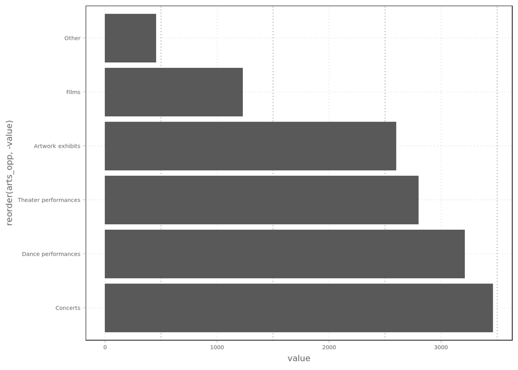

At school, concerts, dance, theater performances and art exhibits are of decreasing frequency. Films are shown less frequently.

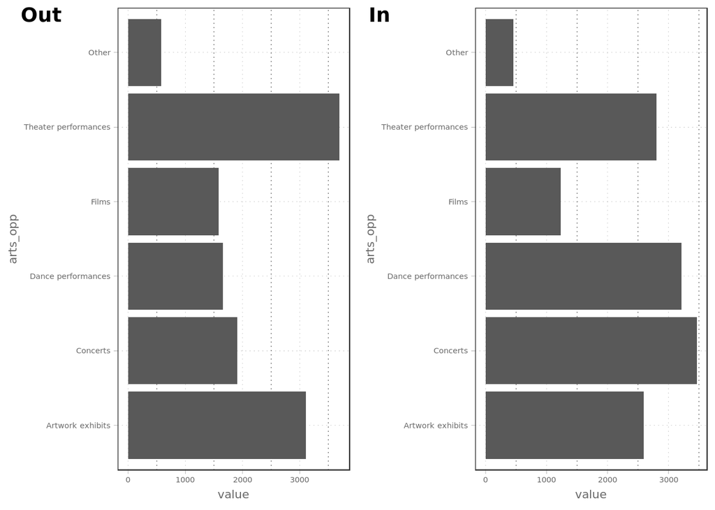

Dance performances and concerts tend to be in schools, theater performances are more likely to be outside of school.

Which is a better predictor of school events, wealth or having an arts program?

To do matching, I should have a better idea of what I am considering “treatment”, “control” and “outcome”.

### Data Provenance

The NYC Department of Education (DOE) has released an annual arts survey report for several years. After separate csv files were downloaded for each source, I changed performance and demographic data into wide format and merged them with the arts survey data on school District Borough Number (DBN).